# Assignment 3: Image Colourization [50 Pt]

In this assignment, you will build models to perform image colourization. That is, given a greyscale image, we wish to predict the colour at each pixel. Image colourization is a difficult problem for many reasons, one of which being that it is ill-posed: for a single greyscale image, there can be multiple, equally valid colourings.

To keep the training time manageable we will use the CIFAR-10 data set, which consists of images of size 32x32 pixels. For most of the questions we will use a subset of the dataset. The data loading script is included with the notebook, and should download automatically the first time it is loaded.

We will be starting with a convolutional autoencoder and tweaking it along the way to improve our perforamnce. Then as a second part of the assignment we will compare the autoencoder approach to conditional generative adversarial networks (cGANs).

In the process, you are expected to learn to:

1. Clean and process the dataset and create greyscale images.
2. Implement and modify an autoencoder architecture.
3. Tune the hyperparameters of an autoencoder.
4. Implement skip connections and other techniques to improve performance.
5. Implement a cGAN and compare with an autoencoder.
6. Improve on the cGAN by trying one of several techniques to enhance training.

*This assignment is based on an assignment developed by Prof. Lisa Zhang and Prof. Jimmy Ba.*

### What to submit

1. Submit the .ipynb and html files containing all your code, outputs, and write-up from parts A and B. Please take extra effort to make your answers and submissions readable. Do not display unnecessary outputs, only the ones that are important for supporting your answers.

You can produce a HTML file directly from Google Colab. The Colab instructions are provided at the end of this document.

2. Colourized images produced by your best model from the provided dataset of grayscale images in Part B.2 saved as "colourized.npz".

**Do not submit any other files produced by your code.**

Include a link to your colab file in your submission.

Please use Google Colab to complete this assignment. If you want to use Jupyter Notebook, please complete the assignment and upload your Jupyter Notebook file to Google Colab for submission.

## Colab Link

Include a link to your Colab file here. If you would like the TA to look at your Colab file in case your solutions are cut off, **please make sure that your Colab file is publicly accessible at the time of submission**.

```python
# TO BE COMPLETED
https://colab.research.google.com/drive/1jhOHvjASbyIe04YWzMODQCXHsqWFfpBs#scrollTo=Qgfuc_PO0_nO
```

# PART A - Autoencoder

In this part we will construct and compare different autoencoder models for the image colourization task.

#### Helper code

Provided are some helper functions for loading and preparing the data. Note that you will need to use the Colab GPU for this assignment.

```python
"""
Colourization of CIFAR-10 Horses via classification.
"""
import argparse
import math
import time

import matplotlib
import matplotlib.pyplot as plt
import numpy as np
import numpy.random as npr
import scipy.misc
import torch
import torch.nn as nn
import torch.nn.functional as F
from torch.autograd import Variable
import logging
# prevent warning messages
logging.getLogger('matplotlib.image').setLevel(logging.ERROR)
```

```python
######################################################################
# Setup working directory
######################################################################
%mkdir -p /content/a3/
%cd /content/a3
```

```
/content/a3
```

```python
######################################################################
# Helper functions for loading data
######################################################################
# adapted from
# https://github.com/fchollet/keras/blob/master/keras/datasets/cifar10.py

import os
import pickle
import sys
import tarfile

import numpy as np
from PIL import Image
from six.moves.urllib.request import urlretrieve


def get_file(fname, origin, untar=False, extract=False, archive_format="auto", cache_dir="data"):
    datadir = os.path.join(cache_dir)
    if not os.path.exists(datadir):
        os.makedirs(datadir)

    if untar:
        untar_fpath = os.path.join(datadir, fname)
        fpath = untar_fpath + ".tar.gz"
    else:
        fpath = os.path.join(datadir, fname)

    print("File path: %s" % fpath)
    if not os.path.exists(fpath):
        print("Downloading data from", origin)

        error_msg = "URL fetch failure on {}: {} -- {}"
        try:
            try:
                urlretrieve(origin, fpath)
            except URLError as e:
                raise Exception(error_msg.format(origin, e.errno, e.reason))
            except HTTPError as e:
                raise Exception(error_msg.format(origin, e.code, e.msg))
        except (Exception, KeyboardInterrupt) as e:
            if os.path.exists(fpath):
                os.remove(fpath)
            raise

    if untar:
        if not os.path.exists(untar_fpath):
            print("Extracting file.")
            with tarfile.open(fpath) as archive:
                archive.extractall(datadir)
        return untar_fpath

    if extract:
        _extract_archive(fpath, datadir, archive_format)

    return fpath


def load_batch(fpath, label_key="labels"):
    """Internal utility for parsing CIFAR data.
    # Arguments
        fpath: path the file to parse.
        label_key: key for label data in the retrieve
            dictionary.
    # Returns
        A tuple `(data, labels)`.
    """
    f = open(fpath, "rb")
    if sys.version_info < (3,):
        d = pickle.load(f)
    else:
        d = pickle.load(f, encoding="bytes")
        # decode utf8
        d_decoded = {}
        for k, v in d.items():
            d_decoded[k.decode("utf8")] = v
        d = d_decoded
    f.close()
    data = d["data"]
    labels = d[label_key]

    data = data.reshape(data.shape[0], 3, 32, 32)
    return data, labels


def load_cifar10(transpose=False):
    """Loads CIFAR10 dataset.
    # Returns
        Tuple of Numpy arrays: `(x_train, y_train), (x_test, y_test)`.
    """
    dirname = "cifar-10-batches-py"
    origin = "http://www.cs.toronto.edu/~kriz/cifar-10-python.tar.gz"
    path = get_file(dirname, origin=origin, untar=True)

    num_train_samples = 50000

    x_train = np.zeros((num_train_samples, 3, 32, 32), dtype="uint8")
    y_train = np.zeros((num_train_samples,), dtype="uint8")

    for i in range(1, 6):
        fpath = os.path.join(path, "data_batch_" + str(i))
        data, labels = load_batch(fpath)
        x_train[(i - 1) * 10000 : i * 10000, :, :, :] = data
        y_train[(i - 1) * 10000 : i * 10000] = labels

    fpath = os.path.join(path, "test_batch")
    x_test, y_test = load_batch(fpath)

    y_train = np.reshape(y_train, (len(y_train), 1))
    y_test = np.reshape(y_test, (len(y_test), 1))

    if transpose:
        x_train = x_train.transpose(0, 2, 3, 1)
        x_test = x_test.transpose(0, 2, 3, 1)
    return (x_train, y_train), (x_test, y_test)
```

```python
# Download CIFAR dataset
m = load_cifar10()
```

```
File path: data/cifar-10-batches-py.tar.gz
Downloading data from http://www.cs.toronto.edu/~kriz/cifar-10-python.tar.gz
Extracting file.
```

## Part 1 Data Preparation [5 pt]

To start off run the above code to load the CIFAR dataset and then work through the following questions/tasks.

### Part (i) [2pt EXPLORATORY]

Verify that the dataset has loaded correctly. How many samples do we have? How is the data organized?

```
Training Data:
Image shape: (50000, 3, 32, 32)
Label Shape (50000, 1)

Testing Data:
Image shape: (10000, 3, 32, 32)
Label Shape (10000, 1)

Distinct Training Labels:
 [0 1 2 3 4 5 6 7 8 9]
Training Labels Distribution:
 [5000 5000 5000 5000 5000 5000 5000 5000 5000 5000]
```

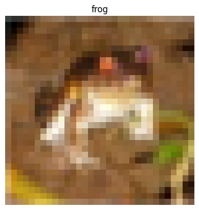

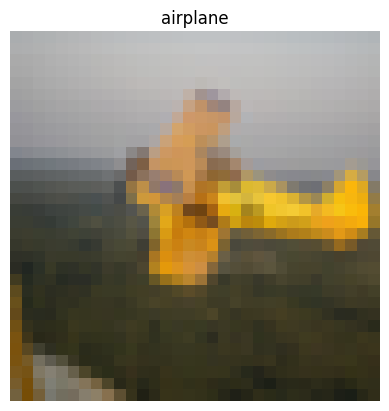

```python
# TO BE COMPLETED

x_train = m[0][0]
y_train = m[0][1]
x_test = m[1][0]
y_test = m[1][1]

# Sample Shape
print('Training Data: \nImage shape:', x_train.shape, '\nLabel Shape', y_train.shape)
print('\nTesting Data: \nImage shape:', x_test.shape, '\nLabel Shape', y_test.shape)

# Sample Distribution & Correct Label Range
vals, cnts = np.unique(y_train.ravel(), return_counts=True)
print('\nDistinct Training Labels:\n', vals)
print('Training Labels Distribution:\n',cnts)


# Several Sample Visualization
CLASSES = ['airplane','automobile','bird','cat','deer','dog','frog','horse','ship','truck']

def show(i=0):
    img = x_train[i]                 # [3,32,32] (NCHW)
    plt.imshow(np.transpose(img, (1,2,0)))  # -> [32,32,3]
    plt.title(CLASSES[int(y_train[i])]); plt.axis('off'); plt.show()

show(0); show(1234)
```

```python
'''
1. Correct Sample Shape:

Training Data:
Image shape: (50000, 3, 32, 32)
Label Shape (50000, 1)

Testing Data:
Image shape: (10000, 3, 32, 32)
Label Shape (10000, 1)


2. Sample Distribution & Correct Label Range

Distinct Training Labels:
 [0 1 2 3 4 5 6 7 8 9]
Training Labels Distribution:
 [5000 5000 5000 5000 5000 5000 5000 5000 5000 5000]


3. Several Sample Visualization
By plotting several images to see if the color channels are correct. The answer is yes.


To sum up, the dataset is loaded properly.

'''
```

[output not shown]

### Part (ii) [3pt EXPLORATORY]

Provided below is sample code to preproces the data to select only images of horses, which will help to simplify the goals of the assignment. The function also converts the colour images to greyscale to create our input data.

```python
# select a single category.
HORSE_CATEGORY = 7

# convert colour images into greyscale
def process(xs, ys, max_pixel=256.0, downsize_input=False):
    """
    Pre-process CIFAR10 images by taking only the horse category,
    shuffling, and have colour values be bound between 0 and 1

    Args:
      xs: the colour RGB pixel values
      ys: the category labels
      max_pixel: maximum pixel value in the original data
    Returns:
      xs: value normalized and shuffled colour images
      grey: greyscale images, also normalized so values are between 0 and 1
    """
    xs = xs / max_pixel
    xs = xs[np.where(ys == HORSE_CATEGORY)[0], :, :, :]
    npr.shuffle(xs)

    grey = np.mean(xs, axis=1, keepdims=True)

    if downsize_input:
        downsize_module = nn.Sequential(
            nn.AvgPool2d(2),
            nn.AvgPool2d(2),
            nn.Upsample(scale_factor=2),
            nn.Upsample(scale_factor=2),
        )
        xs_downsized = downsize_module.forward(torch.from_numpy(xs).float())
        xs_downsized = xs_downsized.data.numpy()
        return (xs, xs_downsized)
    else:
        return (xs, grey)
```

The provided get_batch function creates a dataloader (or function) to batch the samples.

```python
# dataloader for batching samples

def get_batch(x, y, batch_size):
    """
    Generated that yields batches of data

    Args:
      x: input values
      y: output values
      batch_size: size of each batch
    Yields:
      batch_x: a batch of inputs of size at most batch_size
      batch_y: a batch of outputs of size at most batch_size
    """
    N = np.shape(x)[0]
    assert N == np.shape(y)[0]
    for i in range(0, N, batch_size):
        batch_x = x[i : i + batch_size, :, :, :]
        batch_y = y[i : i + batch_size, :, :, :]
        yield (batch_x, batch_y)
```

Run the above helper code and call the appropriate fucntion to verify and visualize that we are able to generate different batches of data with the correct class of images (i.e., horses).

Write code to visualize 5 train and test (validation) images.

```python
# code to load different batches of horse dataset

print("Loading data...")
(x_train, y_train), (x_test, y_test) = load_cifar10()

print("Transforming data...")
train_rgb, train_grey = process(x_train, y_train)
test_rgb, test_grey = process(x_test, y_test)
```

```
Loading data...
File path: data/cifar-10-batches-py.tar.gz
Transforming data...
```

```python
# shape of data and labels before selection
print(x_train.shape, y_train.shape)
```

```
(50000, 3, 32, 32) (50000, 1)
```

```python
# shape of training data
print('Training Data: ', train_rgb.shape, train_grey.shape)
# shape of testing data
print('Testing Data: ', test_rgb.shape, test_grey.shape)
```

```
Training Data:  (5000, 3, 32, 32) (5000, 1, 32, 32)
Testing Data:  (1000, 3, 32, 32) (1000, 1, 32, 32)
```

Load Batches

```python
# TO BE COMPLETED
batch_size = 32
train_batch = get_batch(train_rgb, train_grey, batch_size)
test_batch = get_batch(test_rgb, test_grey, batch_size)

train_x, train_y = next(train_batch)
test_x, test_y = next(test_batch)
```

Write code to visualize 5 train/test images

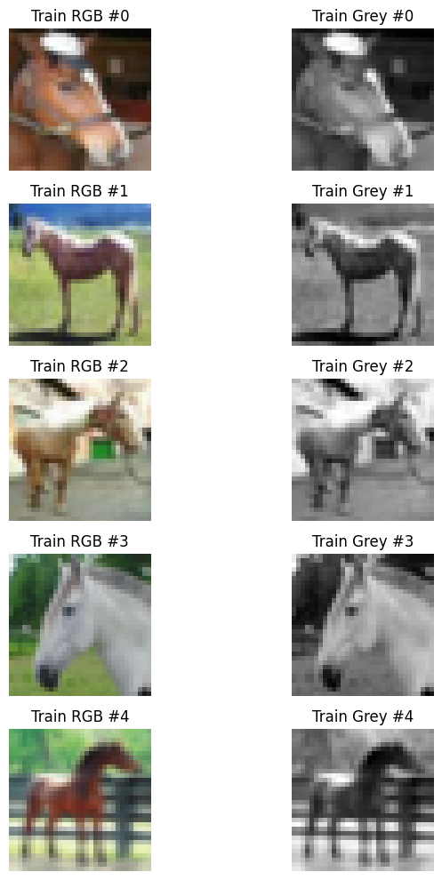

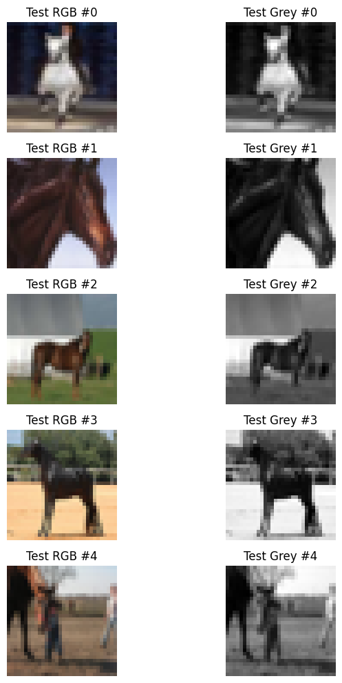

```python
# TO BE COMPLETED

# First 5 Training Images
plt.figure(figsize=(8, 10))
for i in range(5):
    # RGB: NCHW -> HWC
    plt.subplot(5, 2, 2*i+1)
    plt.imshow(np.transpose(train_x[i], (1, 2, 0)))
    plt.title(f'Train RGB #{i}'); plt.axis('off')

    # Grey: [1,H,W] -> [H,W]
    plt.subplot(5, 2, 2*i+2)
    plt.imshow(train_y[i, 0], cmap='gray')
    plt.title(f'Train Grey #{i}'); plt.axis('off')
plt.tight_layout(); plt.show()

# First 5 Test Images
plt.figure(figsize=(8, 10))
for i in range(5):
    plt.subplot(5, 2, 2*i+1)
    plt.imshow(np.transpose(test_x[i], (1, 2, 0)))
    plt.title(f'Test RGB #{i}'); plt.axis('off')

    plt.subplot(5, 2, 2*i+2)
    plt.imshow(test_y[i, 0], cmap='gray')
    plt.title(f'Test Grey #{i}'); plt.axis('off')
plt.tight_layout(); plt.show()
```

## Part 2 Image Colourization as Regression [8 pt]

There are many ways to frame the problem of image colourization as a machine learning problem. One naive approach is to frame it as a regression problem, where we build a model to predict the RGB intensities at each pixel given the greyscale input. In this case, the outputs are continuous, and so squared error can be used to train the model.

In this section, you will be the training neural networks using cloud GPUs. Run the helper code and answer the questions that follow.

#### Helper Code

Regression Architecture

```python
class RegressionCNN(nn.Module):
    def __init__(self, kernel, num_filters):
        # first call parent's initialization function
        super().__init__()
        padding = kernel // 2

        self.downconv1 = nn.Sequential(
            nn.Conv2d(1, num_filters, kernel_size=kernel, padding=padding),
            nn.BatchNorm2d(num_filters),
            nn.ReLU(),
            nn.MaxPool2d(2),)
        self.downconv2 = nn.Sequential(
            nn.Conv2d(num_filters, num_filters*2, kernel_size=kernel, padding=padding),
            nn.BatchNorm2d(num_filters*2),
            nn.ReLU(),
            nn.MaxPool2d(2),)

        self.rfconv = nn.Sequential(
            nn.Conv2d(num_filters*2, num_filters*2, kernel_size=kernel, padding=padding),
            nn.BatchNorm2d(num_filters*2),
            nn.ReLU())

        self.upconv1 = nn.Sequential(
            nn.Conv2d(num_filters*2, num_filters, kernel_size=kernel, padding=padding),
            nn.BatchNorm2d(num_filters),
            nn.ReLU(),
            nn.Upsample(scale_factor=2),)
        self.upconv2 = nn.Sequential(
            nn.Conv2d(num_filters, 3, kernel_size=kernel, padding=padding),
            nn.BatchNorm2d(3),
            nn.ReLU(),
            nn.Upsample(scale_factor=2),)
        self.finalconv = nn.Conv2d(3, 3, kernel_size=kernel, padding=padding)

    def forward(self, x):
        out = self.downconv1(x)
        out = self.downconv2(out)
        out = self.rfconv(out)
        out = self.upconv1(out)
        out = self.upconv2(out)
        out = self.finalconv(out)
        return out
```

Training code

```python
class AttrDict(dict):
    def __init__(self, *args, **kwargs):
        super(AttrDict, self).__init__(*args, **kwargs)
        self.__dict__ = self

def get_torch_vars(xs, ys, gpu=False):
    """
    Helper function to convert numpy arrays to pytorch tensors.
    If GPU is used, move the tensors to GPU.

    Args:
      xs (float numpy tenosor): greyscale input
      ys (int numpy tenosor): rgb as labels
      gpu (bool): whether to move pytorch tensor to GPU
    Returns:
      Variable(xs), Variable(ys)
    """
    xs = torch.from_numpy(xs).float()
    ys = torch.from_numpy(ys).float()
    if gpu:
        xs = xs.cuda()
        ys = ys.cuda()
    return Variable(xs), Variable(ys)


# ======================= Original Train Function =========================
# def train(args, gen=None):

#     # Numpy random seed
#     npr.seed(args.seed)

#     # Save directory
#     save_dir = "outputs/" + args.experiment_name

#     # LOAD THE MODEL
#     if gen is None:
#         Net = globals()[args.model]
#         gen = Net(args.kernel, args.num_filters)

#     # LOSS FUNCTION
#     criterion = nn.MSELoss()
#     optimizer = torch.optim.Adam(gen.parameters(), lr=args.learn_rate)

#     # DATA
#     print("Loading data...")
#     (x_train, y_train), (x_test, y_test) = load_cifar10()

#     print("Transforming data...")
#     train_rgb, train_grey = process(x_train, y_train, downsize_input=args.downsize_input)
#     test_rgb, test_grey = process(x_test, y_test, downsize_input=args.downsize_input)

#     # Create the outputs folder if not created already
#     if not os.path.exists(save_dir):
#         os.makedirs(save_dir)

#     print("Beginning training ...")
#     if args.gpu:
#         gen.cuda()
    # start = time.time()

    # train_losses = []
    # valid_losses = []
    # valid_accs = []
    # for epoch in range(args.epochs):
    #     # Train the Model
    #     gen.train()  # Change model to 'train' mode
    #     losses = []
    #     for i, (xs, ys) in enumerate(get_batch(train_grey, train_rgb, args.batch_size)):
    #         images, labels = get_torch_vars(xs, ys, args.gpu)
    #         # Forward + Backward + Optimize
    #         optimizer.zero_grad()
    #         outputs = gen(images)

    #         loss = criterion(outputs, labels)
    #         loss.backward()
    #         optimizer.step()
    #         losses.append(loss.data.item())

    #     if args.plot and epoch % 5 ==0 :
    #       print(epoch, loss.cpu().detach())
    #       visual(images, labels, outputs, args.gpu, 1)

    # return gen
# =========================================================================

def train(args, gen=None):
  # Fix random seed
  npr.seed(args.seed)

  # Save dir (for CSV only)
  save_dir = os.path.join("outputs", args.experiment_name)
  os.makedirs(save_dir, exist_ok=True)

  # Model
  if gen is None:
      Net = globals()[args.model]
      gen = Net(args.kernel, args.num_filters)

  # Loss & optimizer
  criterion = nn.MSELoss()
  optimizer = torch.optim.Adam(gen.parameters(), lr=args.learn_rate)

  # Data
  print("Loading data...")
  (x_train, y_train), (x_test, y_test) = load_cifar10()

  print("Transforming data...")
  train_rgb, train_grey = process(x_train, y_train, downsize_input=args.downsize_input)
  test_rgb,  test_grey  = process(x_test,  y_test,  downsize_input=args.downsize_input)

  # Device
  if args.gpu:
      gen.cuda()

  print("Beginning training ...")

  train_losses = []  # average train loss per epoch
  csv_path = os.path.join(save_dir, "train_loss_every5.csv")
  # write header if not exists
  if not os.path.exists(csv_path):
      with open(csv_path, "w") as f:
          f.write("epoch,train_loss\n")

  last_images = None
  last_labels = None
  last_outputs = None

  for epoch in range(args.epochs):
      gen.train()
      losses = []

      for i, (xs, ys) in enumerate(get_batch(train_grey, train_rgb, args.batch_size)):
          images, labels = get_torch_vars(xs, ys, args.gpu)

          optimizer.zero_grad()
          outputs = gen(images)
          loss = criterion(outputs, labels)
          loss.backward()
          optimizer.step()

          losses.append(loss.item())

          # keep last batch for final visualization
          last_images, last_labels, last_outputs = images, labels, outputs

      # epoch average loss
      epoch_loss = float(np.mean(losses))
      train_losses.append(epoch_loss)

      # log every 5 epochs (no plotting here)
      if (epoch % 5) == 0:
          with open(csv_path, "a") as f:
              f.write(f"{epoch},{epoch_loss:.8f}\n")
          print(f"[epoch {epoch:03d}] train_loss={epoch_loss:.6f} (logged)")

  # Final: show sample grid + loss curve on screen (do not save)
  visual(last_images, last_labels, last_outputs,
          gpu=args.gpu, flag_torch=1, losses=train_losses)

  # (optional) save model weights
  torch.save(gen.state_dict(), os.path.join(save_dir, "regression_cnn.pt"))
  print("Training done. CSV logged. Loss curve displayed (not saved).")

  return gen
```